# Ames Housing Case

## Q3

> Refit the same model as in Q2, but this time log transform SalePrice. (Use the natural log.) Is this a better model than in Q2? Explain your reasoning.

```r
mlr2<-lm(log(SalePrice) ~ total_sqft + Neighborhood+OverallQual+OverallCond+age+BsmtQual+KitchenQual+GarageCars+GarageQual,data = ahd)
summary(mlr2)
```

```
##
## Call:
## lm(formula = log(SalePrice) ~ total_sqft + Neighborhood + OverallQual +
##     OverallCond + age + BsmtQual + KitchenQual + GarageCars +
##     GarageQual, data = ahd)
##
## Residuals:
##      Min       1Q   Median       3Q      Max
## -1.99869 -0.06577  0.00812  0.07855  0.44121
##
## Coefficients:
##                       Estimate Std. Error t value Pr(>|t|)
## (Intercept)          1.109e+01  1.100e-01 100.820  < 2e-16 ***
## total_sqft           1.751e-04  7.425e-06  23.585  < 2e-16 ***
## NeighborhoodBlueste -8.608e-02  1.114e-01  -0.773 0.439606
## NeighborhoodBrDale  -1.618e-01  5.398e-02  -2.998 0.002768 **
## NeighborhoodBrkSide -2.918e-03  4.624e-02  -0.063 0.949684
## NeighborhoodClearCr  2.091e-01  4.736e-02   4.414 1.09e-05 ***
## NeighborhoodCollgCr  8.503e-02  3.804e-02   2.235 0.025576 *
## NeighborhoodCrawfor  1.914e-01  4.546e-02   4.210 2.71e-05 ***
## NeighborhoodEdwards -3.431e-02  4.211e-02  -0.815 0.415291
## NeighborhoodGilbert  1.172e-01  3.986e-02   2.940 0.003336 **
## NeighborhoodIDOTRR  -1.522e-01  4.913e-02  -3.098 0.001985 **
## NeighborhoodMeadowV -1.540e-01  5.316e-02  -2.897 0.003827 **
## NeighborhoodMitchel  3.086e-02  4.317e-02   0.715 0.474818
## NeighborhoodNAmes    3.364e-02  4.051e-02   0.830 0.406437
## NeighborhoodNoRidge  2.168e-01  4.352e-02   4.981 7.10e-07 ***
## NeighborhoodNPkVill -4.234e-02  6.205e-02  -0.682 0.495153
## NeighborhoodNridgHt  1.666e-01  4.091e-02   4.073 4.91e-05 ***
## NeighborhoodNWAmes   5.084e-02  4.140e-02   1.228 0.219637
## NeighborhoodOldTown -7.944e-02  4.503e-02  -1.764 0.077886 .
## NeighborhoodSawyer   2.749e-02  4.283e-02   0.642 0.521011
## NeighborhoodSawyerW  7.063e-02  4.120e-02   1.714 0.086702 .
## NeighborhoodSomerst  1.207e-01  3.929e-02   3.071 0.002175 **
## NeighborhoodStoneBr  2.105e-01  4.706e-02   4.472 8.36e-06 ***
## NeighborhoodSWISU    4.108e-02  5.215e-02   0.788 0.430930
## NeighborhoodTimber   1.400e-01  4.356e-02   3.214 0.001339 **
## NeighborhoodVeenker  1.806e-01  5.796e-02   3.115 0.001877 **
## OverallQual          6.651e-02  5.360e-03  12.410  < 2e-16 ***
## OverallCond          5.457e-02  4.183e-03  13.045  < 2e-16 ***
## age                 -1.497e-03  3.235e-04  -4.627 4.06e-06 ***
## BsmtQualFa          -9.607e-02  3.608e-02  -2.662 0.007847 **
## BsmtQualGd          -6.069e-02  1.881e-02  -3.226 0.001283 **
## BsmtQualnone        -7.129e-02  3.480e-02  -2.048 0.040711 *
## BsmtQualTA          -8.380e-02  2.316e-02  -3.618 0.000307 ***
## KitchenQualFa       -1.234e-01  3.401e-02  -3.628 0.000296 ***
## KitchenQualGd       -5.315e-02  1.954e-02  -2.720 0.006611 **
## KitchenQualTA       -8.684e-02  2.192e-02  -3.961 7.82e-05 ***
## GarageCars           7.103e-02  8.942e-03   7.944 3.97e-15 ***
## GarageQualFa        -2.437e-01  8.933e-02  -2.728 0.006451 **
## GarageQualGd        -1.300e-01  9.509e-02  -1.368 0.171678
## GarageQualnone      -2.272e-01  8.930e-02  -2.544 0.011056 *
## GarageQualPo        -3.386e-01  1.231e-01  -2.750 0.006030 **
## GarageQualTA        -1.909e-01  8.664e-02  -2.203 0.027739 *
## ---
## Signif. codes:  0 '***' 0.001 '**' 0.01 '*' 0.05 '.' 0.1 ' ' 1
##
## Residual standard error: 0.1479 on 1418 degrees of freedom
## Multiple R-squared:  0.8668, Adjusted R-squared:  0.8629
## F-statistic:   225 on 41 and 1418 DF,  p-value: < 2.2e-16
```

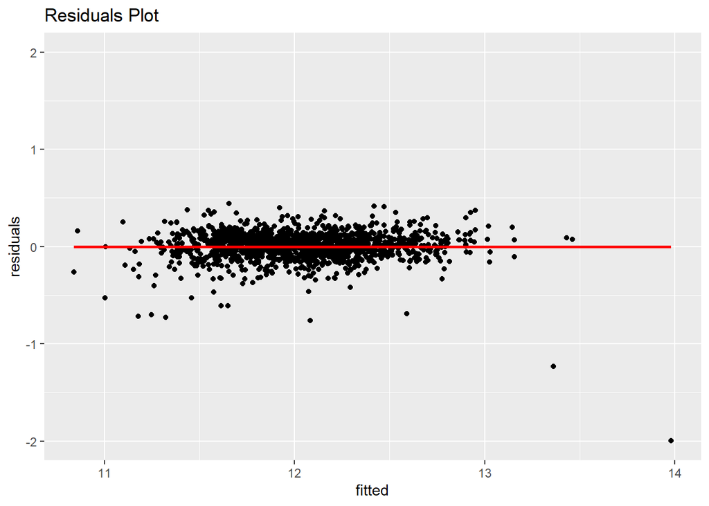

```r
plot<-ahd %>%
  mutate(fitted = fitted(mlr2),
         residuals = resid(mlr2)) %>%
  ggplot(aes(fitted, residuals)) +
  geom_point() +
  geom_smooth(formula=y~x,method = "lm", se = F, col = "red")+ylim(-2, 2)+labs(title = "Residuals Plot")
plot
```

> To choose between two multiple regression models, we need to select the one with the high Adjusted R2 value, and the model has equally distributed residuals around zero. The resulting model in Q3 has a higher adjusted R2 of 0.8629 than the Q2 model, which is 0.8363. In addition, when we compare the two models’ residual plots, the Q3 model is more equally distributed residuals around zero than the Q2 model. To conclude Q3 model is better than the Q2 model.